# Does Getting Richer Mean Polluting More?

Income and per-capita CO₂ emissions across 164 countries, 2000–2022

Soham Athawale (s4233801)

Last updated: 16 October, 2026

# Introduction

- Carbon dioxide (CO₂) from burning fossil fuels and making cement is the main driver of global warming. Annual emissions reached about **38.6 billion tonnes** in 2024 (Friedlingstein et al., 2025).
- Rich and poor countries emit very different amounts. In 2022 the average person in Qatar emitted about 38 t of CO₂, as much as **more than 500 people in Somalia or the DR Congo**.
- This leads to two big questions in climate policy:
  - **Is emitting tied to wealth?** If CO₂ rises with income, emissions will keep growing as poorer countries develop (about 6.6 billion of the world’s 8 billion people live in low- or middle-income countries).
  - **Are rich countries “decoupling”?** Can they keep income high while cutting emissions? This idea underlies the *Environmental Kuznets Curve* (EKC), which says pollution first rises and then falls as income grows (Grossman & Krueger, 1995).

**Key terms**

- **CO₂ per capita**: a country’s annual fossil and industrial CO₂ emissions (tonnes) divided by its population.
- **GDP per capita**: economic output per person, adjusted for inflation and living costs. It is measured in *international dollars* (2011 prices), so countries can be compared fairly.
- **Elasticity**: the % change in CO₂ per capita that goes with a 1% change in GDP per capita.

# Problem Statement

**Overall question:** *How closely are a country’s CO₂ emissions per person tied to its income, and has that link changed since 2000?*

| # | Research question | Statistical method |
| --- | --- | --- |
| RQ1 | Did the average country’s CO₂ per capita change between 2000 and 2022? | Paired-samples *t*-test and 95% CI (Task 5) |
| RQ2 | Did that change differ between countries that were richer and poorer in 2000? | Welch two-sample *t*-test and 95% CI (Task 5) |
| RQ3 | How strongly does GDP per capita predict CO₂ per capita in 2022, and is the relationship proportional (elasticity = 1)? | Simple linear regression on the log–log scale (Task 7) |

- I first summarise the data with descriptive statistics and plots. Next I state the hypotheses, check the assumptions and report the test statistics, *p*-values and CIs (α = 0.05). Finally I interpret the results for a climate-policy audience.

# Data: Source and Collection

- **Source:** Our World in Data (OWID) *CO₂ and Greenhouse Gas Emissions* dataset (Ritchie, Rosado & Roser, 2023), downloaded from the official GitHub repository on 16 October 2026: https://github.com/owid/co2-data.
- **Licence:** Creative Commons **CC BY 4.0**, so the data are open and can be shared with attribution.
- **How OWID compiled it** (secondary data; I did not collect it):
  - **CO₂ emissions:** *Global Carbon Budget 2025* (Friedlingstein et al., 2025). National energy and industry statistics are converted to CO₂ using fuel-specific emission factors. This covers territorial emissions only and excludes land-use change.
  - **GDP:** *Maddison Project Database 2023* (Bolt & van Zanden, 2024), in 2011 international $.
  - **Population:** OWID’s long-run population series, mainly UN *World Population Prospects*.
- **Sampling:** There is no random sample. The dataset aims to be a **census of all countries**, and the analysis set is every country with complete data. Results therefore describe *countries* (each country counts once, whatever its population), not individual people.
- **Regions:** I added a continent for each country from the open *ISO-3166 Countries with Regional Codes* list (Duncalf, 2024; CC BY-SA 4.0), joined on the 3-letter ISO code.
- **Replication:** Download `owid-co2-data.csv`, keep the rows for 2000 and 2022, and run the pre-processing code on the next slides. A copy of the snapshot used here is in `data/`.

# Data: Variables

| Variable | Description | Type / scale | Units |
| --- | --- | --- | --- |
| `country`, `iso_code` | Country name and ISO 3166-1 alpha-3 code | Identifier | – |
| `year` | Year of observation (2000 or 2022) | Discrete | year |
| `population` | Mid-year population | Ratio | people |
| `gdp` | Real GDP, adjusted for purchasing power (PPP) | Ratio | 2011 international $ |
| `co2_per_capita` | Fossil and industry CO₂ per person | Ratio | tonnes / person / year |
| `gdppc` *(derived)* | `gdp / population`, i.e. GDP per capita | Ratio | int-$ / person |
| `change` *(derived)* | CO₂ per capita in 2022 minus 2000 | Interval | tonnes / person |
| `income_2000` *(derived)* | Factor with 2 levels: **Poorer half** / **Richer half**, split at the median 2000 GDP per capita | Nominal | – |
| `region` *(joined)* | Factor with 4 levels: **Africa**, **Americas**, **Asia & Oceania**, **Europe** | Nominal | – |

- **Why 2000 and 2022?** 2022 is the latest year with GDP data (Maddison ends in 2022). 2000 gives a 22-year comparison window, and from 2000 onward almost every current country exists with its present borders.

# Data: Pre-processing

```r
co2 <- read_csv("data/owid-co2-2000-2022.csv")     # 2000 & 2022 rows of owid-co2-data.csv
iso <- read_csv("data/iso3166-regions.csv")         # ISO code -> continent lookup

countries <- co2 %>%
  filter(!is.na(iso_code)) %>%                    # drop aggregates (World, continents, income groups)
  select(country, iso_code, year, population, gdp, co2_per_capita) %>%
  pivot_wider(names_from = year, values_from = c(population, gdp, co2_per_capita))

n_all <- nrow(countries)
world_pop <- co2$population[co2$country == "World" & co2$year == 2022]

dat <- countries %>%
  drop_na() %>%                                             # complete cases in both years
  mutate(gdppc_2000 = gdp_2000 / population_2000,
         gdppc_2022 = gdp_2022 / population_2022,
         change     = co2_per_capita_2022 - co2_per_capita_2000,
         income_2000 = factor(ifelse(gdppc_2000 > median(gdppc_2000), "Richer half", "Poorer half"),
                              levels = c("Poorer half", "Richer half"))) %>%
  left_join(select(iso, iso_code = `alpha-3`, region), by = "iso_code") %>%
  mutate(region = case_when(iso_code == "TWN" ~ "Asia",          # Taiwan is not in the ISO list
                            TRUE ~ region),
         region = factor(ifelse(region %in% c("Asia", "Oceania"), "Asia & Oceania", region)))
```

- **Aggregates:** I removed rows with no ISO code. These are groups of countries (the world, continents, income groups) rather than single countries, and keeping them would count some countries twice.
- **Missing data:** 218 countries and territories have an ISO code. Of these, **54** have no GDP or CO₂ value in at least one year, so I removed them. Most are micro-states and small islands (e.g. Monaco, Tuvalu), plus Somalia, Sudan/South Sudan and Eritrea. Imputing values is not justified for whole-economy figures. **Final analysis set: n = 164 countries**, about 99% of the world’s population.
- Oceania has only 2 countries left (Australia and New Zealand), so I merged it with Asia for the plots.

# Descriptive Statistics

```r
summ <- function(x) c(Min = min(x), Q1 = quantile(x, .25, names = FALSE), Median = median(x),
                      Q3 = quantile(x, .75, names = FALSE), Max = max(x), Mean = mean(x),
                      SD = sd(x), n = length(x), Missing = sum(is.na(x)))
tab <- rbind(`CO₂ per capita 2000 (t)`  = summ(dat$co2_per_capita_2000),
             `CO₂ per capita 2022 (t)`  = summ(dat$co2_per_capita_2022),
             `Change 2000→2022 (t)`     = summ(dat$change),
             `GDP per capita 2022 (int-$ '000)` = summ(dat$gdppc_2022 / 1000))
kable(tab, digits = 2)
```

|  | Min | Q1 | Median | Q3 | Max | Mean | SD | n | Missing |
| --- | --- | --- | --- | --- | --- | --- | --- | --- | --- |
| CO₂ per capita 2000 (t) | 0.03 | 0.62 | 2.33 | 7.01 | 62.65 | 4.90 | 7.31 | 164 | 0 |
| CO₂ per capita 2022 (t) | 0.06 | 0.83 | 2.84 | 6.07 | 37.89 | 4.53 | 5.57 | 164 | 0 |
| Change 2000→2022 (t) | -24.76 | -1.15 | 0.12 | 0.68 | 8.92 | -0.38 | 3.07 | 164 | 0 |
| GDP per capita 2022 (int-$ ’000) | 0.69 | 4.43 | 12.61 | 27.42 | 131.99 | 19.15 | 20.05 | 164 | 0 |

- **Strong right skew.** In 2022 the mean CO₂ per capita (4.53 t) is much higher than the median (2.84 t), and the same holds for GDP per capita. A few very rich, oil-producing countries pull the means up.
- **Huge range:** from 0.06 t (Democratic Republic of Congo) to 37.89 t (Qatar) per person, about 653 times higher.
- **Change since 2000:** the median country *increased* by 0.12 t, but the mean change is *negative* (-0.38 t). A few large falls drive the mean down, which points to opposite trends in different groups of countries.

# Visualisation: Distributions and the Log Scale

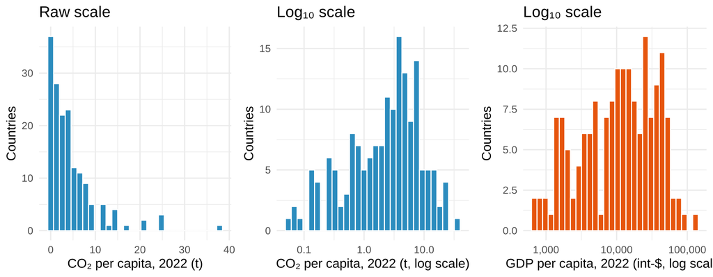

```r
p1 <- ggplot(dat, aes(co2_per_capita_2022)) +
  geom_histogram(bins = 30, fill = "#2b8cbe", colour = "white") +
  labs(title = "Raw scale", x = "CO₂ per capita, 2022 (t)", y = "Countries")
p2 <- ggplot(dat, aes(co2_per_capita_2022)) +
  geom_histogram(bins = 30, fill = "#2b8cbe", colour = "white") + scale_x_log10() +
  labs(title = "Log₁₀ scale", x = "CO₂ per capita, 2022 (t, log scale)", y = "Countries")
p3 <- ggplot(dat, aes(gdppc_2022)) +
  geom_histogram(bins = 30, fill = "#e6550d", colour = "white") + scale_x_log10(labels = scales::comma) +
  labs(title = "Log₁₀ scale", x = "GDP per capita, 2022 (int-$, log scale)", y = "Countries")
grid.arrange(p1, p2, p3, ncol = 3)
```

- On the raw scale, CO₂ per capita is strongly right-skewed with a long upper tail (Gulf states, Trinidad & Tobago). On the **log₁₀ scale** both CO₂ and GDP per capita look roughly symmetric.
- **Outliers:** the extreme values are real countries with genuine data (e.g. Qatar’s oil and gas industry), not recording errors, so **I kept them**. I **log-transformed** the variables for the regression and checked how much the extreme cases influence each test.

# Visualisation: Emissions by Region

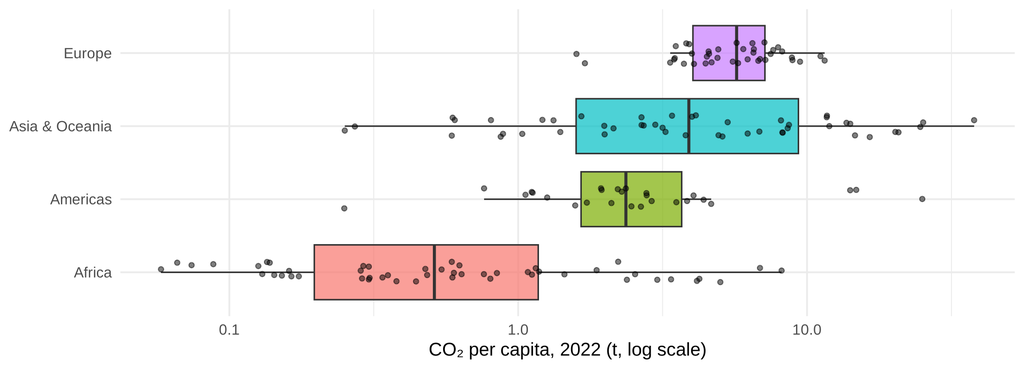

```r
ggplot(dat, aes(x = reorder(region, co2_per_capita_2022, median), y = co2_per_capita_2022, fill = region)) +
  geom_boxplot(alpha = .7, outlier.shape = NA, show.legend = FALSE) +
  geom_jitter(width = .15, alpha = .5, size = 1.4, show.legend = FALSE) +
  scale_y_log10() + coord_flip() +
  labs(x = NULL, y = "CO₂ per capita, 2022 (t, log scale)")
```

```r
dat %>% group_by(Region = region) %>%
  summarise(n = n(), `Median CO₂ pc (t)` = median(co2_per_capita_2022),
            `Median GDP pc (int-$)` = median(gdppc_2022)) %>%
  arrange(`Median CO₂ pc (t)`) %>% kable(digits = 2, format.args = list(big.mark = ","))
```

| Region | n | Median CO₂ pc (t) | Median GDP pc (int-$) |
| --- | --- | --- | --- |
| Africa | 50 | 0.51 | 2,990.05 |
| Americas | 27 | 2.36 | 10,206.82 |
| Asia & Oceania | 48 | 3.90 | 13,636.79 |
| Europe | 39 | 5.70 | 32,069.76 |

- Regions rank the same way on CO₂ per capita as on GDP per capita. Africa is lowest on both and Europe is highest on both, which suggests that income is the common factor.

# Visualisation: Income vs Emissions (2022)

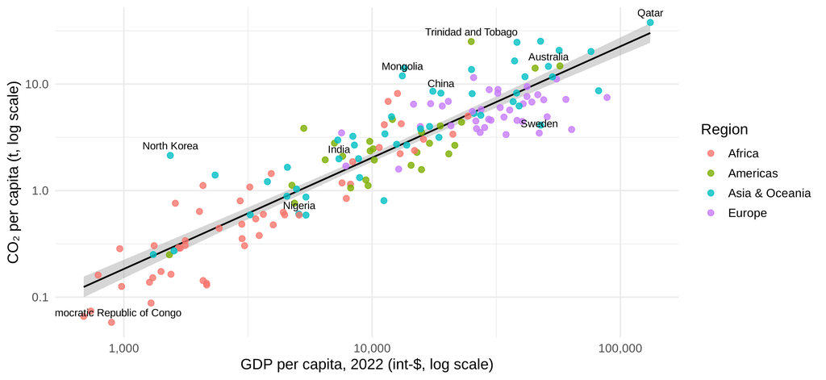

```r
lab <- dat %>% filter(country %in% c("Qatar", "United States", "China", "India", "Australia",
                                     "Switzerland", "Nigeria", "Democratic Republic of Congo",
                                     "Trinidad and Tobago", "North Korea", "Sweden", "Mongolia"))
ggplot(dat, aes(gdppc_2022, co2_per_capita_2022)) +
  geom_smooth(method = "lm", formula = y ~ x, colour = "black", linewidth = .7) +
  geom_point(aes(colour = region), size = 2.2, alpha = .8) +
  geom_text(data = lab, aes(label = country), size = 3.2, vjust = -0.8, check_overlap = TRUE) +
  scale_x_log10(labels = scales::comma) + scale_y_log10() +
  labs(x = "GDP per capita, 2022 (int-$, log scale)", y = "CO₂ per capita (t, log scale)", colour = "Region")
```

- On the log–log scale the relationship is **strong, positive and close to linear** (Pearson *r* = 0.91).
- The spread of points around the line looks fairly even. North Korea and Mongolia lie above the line (coal-heavy economies), while Switzerland and Sweden lie below it (low-carbon electricity from hydro and nuclear power).

# Visualisation: How Did Emissions Change, 2000→2022?

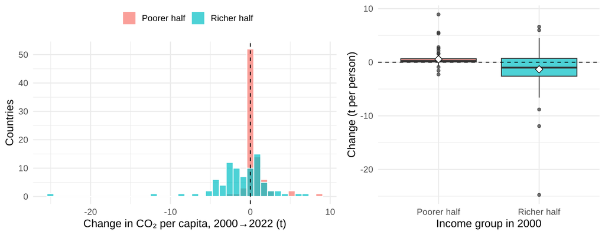

```r
q1 <- ggplot(dat, aes(change, fill = income_2000)) +
  geom_histogram(bins = 40, colour = "white", position = "identity", alpha = .7) +
  geom_vline(xintercept = 0, linetype = 2) +
  labs(x = "Change in CO₂ per capita, 2000→2022 (t)", y = "Countries", fill = NULL) +
  theme(legend.position = "top")
q2 <- ggplot(dat, aes(income_2000, change, fill = income_2000)) +
  geom_boxplot(alpha = .7, show.legend = FALSE) + geom_hline(yintercept = 0, linetype = 2) +
  stat_summary(fun = mean, geom = "point", shape = 23, size = 3, fill = "white") +
  labs(x = "Income group in 2000", y = "Change (t per person)")
grid.arrange(q1, q2, ncol = 2, widths = c(1.3, 1))
```

- 102 of 164 countries (62%) *increased* their per-capita emissions. However, **most countries in the richer half reduced** their emissions, while **most in the poorer half increased** them. (◇ = group mean)
- The changes are heavy-tailed. Qatar (-24.8 t) and the UAE (-11.9 t) are extreme low outliers, and the richer half varies much more than the poorer half.

# Hypothesis Test 1: Paired-Samples *t*-Test

**RQ1 — Did the average country’s CO₂ per capita change between 2000 and 2022?** Each country is measured twice, so the two samples are **dependent**. I therefore analyse the within-country differences $d_i = \text{CO}_{2,2022} - \text{CO}_{2,2000}$.

$$H_0: \mu_\Delta = 0 \qquad H_A:
\mu_\Delta \ne 0 \qquad (\alpha = 0.05)$$

**Assumptions**

- **Paired, dependent observations:** yes, the same country is measured in both years.
- **The differences are approximately normal *or* n is large:** the Q–Q plot below shows heavy tails (Qatar, UAE, Mongolia). However, n = 164 > 30, so by the Central Limit Theorem the sampling distribution of $\bar d$ is approximately normal and the *t*-test is valid.

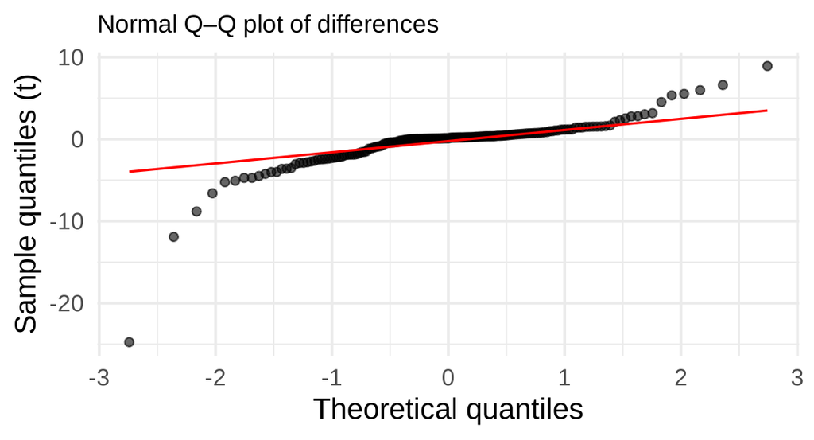

```r
ggplot(dat, aes(sample = change)) + stat_qq(alpha = .6) + stat_qq_line(colour = "red") +
  labs(x = "Theoretical quantiles", y = "Sample quantiles (t)", title = "Normal Q–Q plot of differences") +
  theme(plot.title = element_text(size = 11))
```

# Hypothesis Test 1: Results

```r
ptest <- t.test(dat$co2_per_capita_2022, dat$co2_per_capita_2000, paired = TRUE, conf.level = 0.95)
ptest
```

```
##
##  Paired t-test
##
## data:  dat$co2_per_capita_2022 and dat$co2_per_capita_2000
## t = -1.5833, df = 163, p-value = 0.1153
## alternative hypothesis: true mean difference is not equal to 0
## 95 percent confidence interval:
##  -0.85161814  0.09366692
## sample estimates:
## mean difference
##      -0.3789756
```

- **Mean difference** $\bar d$ = -0.38 t per person, *t*(163) = -1.58, *p* = 0.115.
- **95% CI for $\mu_\Delta$:** [-0.85, 0.09] t. The interval **contains 0**, which agrees with the *p*-value.
- **Decision:** *p* > 0.05, so we **fail to reject H₀**. There is no statistically significant evidence that the average country’s CO₂ per capita changed between 2000 and 2022.
- **Interpretation:** across countries, the global average has not clearly moved in 22 years. This “no change” result is misleading, though: the descriptive plots suggest that falls in rich countries and rises in poor countries cancel out. The next test checks this.
- *Robustness check:* a Wilcoxon signed-rank test, which is less sensitive to the heavy tails, reaches the **same conclusion** (*p* = 0.834). Neither the mean nor the typical (median) country changed significantly.

# Hypothesis Test 2: Welch Two-Sample *t*-Test

**RQ2 — Did the change in CO₂ per capita differ between countries that were richer and poorer in 2000?**

$$H_0: \mu_{\Delta,\text{poorer}} -
\mu_{\Delta,\text{richer}} = 0 \qquad H_A: \mu_{\Delta,\text{poorer}} -
\mu_{\Delta,\text{richer}} \ne 0$$

```r
dat %>% group_by(income_2000) %>%
  summarise(n = n(), Mean = mean(change), SD = sd(change), Median = median(change)) %>% kable(digits = 2)
```

| income_2000 | n | Mean | SD | Median |
| --- | --- | --- | --- | --- |
| Poorer half | 82 | 0.56 | 1.42 | 0.23 |
| Richer half | 82 | -1.32 | 3.88 | -1.00 |

```r
lev <- leveneTest(change ~ income_2000, data = dat)
```

**Assumptions**

- **Independent groups:** yes, each country belongs to exactly one income group.
- **Normality / large samples:** n = 82 per group, which is more than 30, so the CLT applies even though the richer group is heavy-tailed.
- **Equal variances?** Levene’s test: *F*(1, 162) = 23.73, *p* < .001. Equal variances are **rejected** (SD 3.88 vs 1.42), so I use **Welch’s *t*-test**, which does not assume equal variances.

# Hypothesis Test 2: Results

```r
wt <- t.test(change ~ income_2000, data = dat, var.equal = FALSE)
wt
```

```
##
##  Welch Two Sample t-test
##
## data:  change by income_2000
## t = 4.1312, df = 102.3, p-value = 7.39e-05
## alternative hypothesis: true difference in means between group Poorer half and group Richer half is not equal to 0
## 95 percent confidence interval:
##  0.980979 2.792777
## sample estimates:
## mean in group Poorer half mean in group Richer half
##                 0.5644634                -1.3224146
```

- The poorer half **rose** by 0.56 t per person on average, and the richer half **fell** by 1.32 t per person.
- **Welch** *t*(102.3) = 4.13, *p* < .001. **95% CI for the difference in mean change:** [0.98, 2.79] t, which **does not contain 0**.
- **Decision:** *p* < 0.05, so we **reject H₀**. The change in per-capita emissions differed significantly by income group.
- **Interpretation:** we are 95% confident that the average change in poorer countries was between 0.98 and 2.79 t per person **higher** than in richer countries. Rich and poor countries are **converging** toward each other.
- *Sensitivity:* without the two largest outliers (Qatar and UAE), the difference is still significant (1.46 t, *p* < .001), so the result does not depend on those two countries.

# Regression: Model and Hypotheses

**RQ3 — How strongly does income predict emissions?** Both variables are right-skewed, so I fit a **log–log** simple linear regression for 2022:

$$\log_{10}(\text{CO}_2\text{pc}_i) =
\beta_0 + \beta_1 \log_{10}(\text{GDPpc}_i) + \varepsilon_i,\qquad
\varepsilon_i \sim N(0,\sigma^2)$$

In this model $\beta_1$ is an **elasticity**: a 1% higher GDP per capita goes with about $\beta_1$% higher CO₂ per capita.

- **Overall model / slope:** $H_0: \beta_1 = 0$ (GDP per capita does not predict CO₂) vs $H_A: \beta_1 \ne 0$.
- **Proportionality:** $H_0: \beta_1 = 1$ (emissions rise in proportion to income) vs $H_A: \beta_1 \ne 1$.

```r
mod <- lm(log10(co2_per_capita_2022) ~ log10(gdppc_2022), data = dat)
summary(mod)
```

```
##
## Call:
## lm(formula = log10(co2_per_capita_2022) ~ log10(gdppc_2022),
##     data = dat)
##
## Residuals:
##      Min       1Q   Median       3Q      Max
## -0.57472 -0.17521 -0.02901  0.15647  0.87023
##
## Coefficients:
##                   Estimate Std. Error t value Pr(>|t|)
## (Intercept)       -3.86910    0.15457  -25.03   <2e-16 ***
## log10(gdppc_2022)  1.04455    0.03811   27.41   <2e-16 ***
## ---
## Signif. codes:  0 '***' 0.001 '**' 0.01 '*' 0.05 '.' 0.1 ' ' 1
##
## Residual standard error: 0.258 on 162 degrees of freedom
## Multiple R-squared:  0.8226, Adjusted R-squared:  0.8215
## F-statistic: 751.2 on 1 and 162 DF,  p-value: < 2.2e-16
```

# Regression: Checking Assumptions

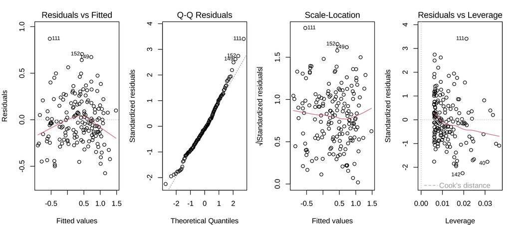

```r
par(mfrow = c(1, 4), mar = c(4, 4, 2.5, 1), cex = .85)
plot(mod, which = c(1, 2, 3, 5))
```

- **Linearity:** the Residuals vs Fitted plot shows a fairly flat trend with a slight downward bend at the top end (checked on the next slide).
- **Independence:** each country is a separate observation. Neighbouring countries can share energy systems, which is a minor concern (see Discussion).
- **Normality of residuals:** the Q–Q plot is close to the line, with a slightly heavy upper tail (North Korea and Mongolia are above the line).
- **Homoscedasticity:** the Scale–Location plot is roughly flat, so the residual spread is fairly constant.
- **Influential points:** every Cook’s distance is far below 0.5 (max = 0.126, North Korea), so no single country drives the fit.
- **Conclusion:** the assumptions are reasonably satisfied, so inference from the model is appropriate.

# Regression: Results and Interpretation

```r
ci <- confint(mod)
t_b1_eq1 <- (coef(mod)[2] - 1) / summary(mod)$coef[2, 2]
p_b1_eq1 <- 2 * pt(-abs(t_b1_eq1), df = mod$df.residual)
quad <- lm(log10(co2_per_capita_2022) ~ log10(gdppc_2022) + I(log10(gdppc_2022)^2), data = dat)
kable(data.frame(Term = c("Intercept", "log10(GDP pc)"), Estimate = coef(mod),
                 `2.5%` = ci[, 1], `97.5%` = ci[, 2], check.names = FALSE), digits = 3, row.names = FALSE)
```

| Term | Estimate | 2.5% | 97.5% |
| --- | --- | --- | --- |
| Intercept | -3.869 | -4.174 | -3.564 |
| log10(GDP pc) | 1.045 | 0.969 | 1.120 |

- **Model fit:** *F*(1, 162) = 751.2, *p* < .001, **R² = 0.823**. Income alone explains about **82%** of the variation in log CO₂ per capita.
- **Slope:** $\hat\beta_1$ = 1.045, 95% CI [0.969, 1.120], *p* < .001. **We reject $H_0: \beta_1 = 0$.** A country with **10% higher** GDP per capita emits about **10.5% more** CO₂ per person.
- **Proportionality:** *t* = 1.17, *p* = 0.244. The CI contains 1, so we **fail to reject $H_0: \beta_1 = 1$**. Across countries, emissions rise roughly **one-for-one** with income, so the CO₂ emitted per dollar of GDP is broadly similar at all income levels.
- **Curvature check (EKC):** adding a squared term gives a negative coefficient (-0.212, *p* = 0.002), so the curve **flattens** at high incomes. However, its turning point (≈ int-$2.5 million per person) is far outside the data. **There is no peak: richer countries never emit less on average.**

# Discussion: Major Findings

1. **Income is a very strong predictor of emissions.** GDP per capita explains about 82% of the cross-country variation in (log) CO₂ per capita. The elasticity is about 1.04, and its CI contains 1, so emissions rise roughly in proportion to income. A curvature term shows flattening at the top but **no turning point**, which gives little support to an EKC peak within the observed range of income.
2. **The average country did not change significantly** from 2000 to 2022 (paired *t*-test, *p* = 0.115). This average hides two opposite trends.
3. **Rich and poor countries moved in opposite directions.** The richer half cut per-capita emissions by about 1.3 t on average, while the poorer half added about 0.6 t. The difference is highly significant (Welch *p* < .001, 95% CI [0.98, 2.79] t) and remains significant without the outliers.

**Putting it together:** rich countries *have* started to cut their own emissions (time trend), yet they are still the highest emitters per person (cross-section). Meanwhile, the rising emissions of developing countries follow the same income–CO₂ line. If those countries grow along that line, global emissions will rise unless low-carbon energy changes the relationship.

# Discussion: Strengths, Limitations and Future Work

**Strengths**

- Open, authoritative data (Global Carbon Budget and Maddison) covering about 99% of the world’s population, with a fully reproducible pipeline.
- Each method matches its question: a paired design for repeated measures, Welch’s test for unequal variances, and a log–log model for skewed ratio data. All assumptions were checked, and sensitivity analyses (Wilcoxon test, removing outliers, a quadratic term) support the conclusions.

**Limitations**

- **Observational data**, so the regression shows **association, not causation**. Climate, fossil-fuel resources and energy mix also matter.
- **Countries are unweighted:** Luxembourg counts as much as China. The results describe the “average country”, not the average person.
- **Territorial emissions only:** rich countries “import” emissions in the goods they buy (Peters et al., 2011), so their reported cuts overstate their real decoupling.
- Small and conflict-affected states are missing (not missing at random), and neighbouring countries may not be fully independent.

**Future directions:** use consumption-based CO₂ data, fit population-weighted or panel models over every year, and add the energy mix (share of renewables) as a second predictor in a multiple regression.

**Take-home message:** *Across countries, CO₂ per person still rises almost one-for-one with income. Rich countries have begun to cut emissions while poorer countries’ emissions rise, so global climate goals depend on helping developing countries grow on a cleaner path than rich countries took.*

# References

- Bolt, J., & van Zanden, J. L. (2024). Maddison style estimates of the evolution of the world economy: A new 2023 update. *Journal of Economic Surveys*, 1–41. https://doi.org/10.1111/joes.12618
- Duncalf, L. (2024). *ISO-3166 Countries with Regional Codes* [Data set]. GitHub. https://github.com/lukes/ISO-3166-Countries-with-Regional-Codes (CC BY-SA 4.0)
- Friedlingstein, P., et al. (2025). Global Carbon Budget 2025. *Earth System Science Data*. https://globalcarbonbudget.org/
- Grossman, G. M., & Krueger, A. B. (1995). Economic growth and the environment. *The Quarterly Journal of Economics*, 110(2), 353–377. https://doi.org/10.2307/2118443
- Peters, G. P., Minx, J. C., Weber, C. L., & Edenhofer, O. (2011). Growth in emission transfers via international trade from 1990 to 2008. *PNAS*, 108(21), 8903–8908. https://doi.org/10.1073/pnas.1006388108
- Ritchie, H., Rosado, P., & Roser, M. (2023). *CO₂ and greenhouse gas emissions* [Data set]. Our World in Data. https://github.com/owid/co2-data (CC BY 4.0). Retrieved 16 October 2026.
- R Core Team (2024). *R: A language and environment for statistical computing*. R Foundation for Statistical Computing. https://www.R-project.org/
- Wickham, H., et al. (2019). Welcome to the tidyverse. *Journal of Open Source Software*, 4(43), 1686. https://doi.org/10.21105/joss.01686
- Fox, J., & Weisberg, S. (2019). *An R companion to applied regression* (3rd ed.). Sage. (`car` package)